# Bellabeat Case Study using R

Michelle Chan

2022-04-18

## Background

Bellabeat is a health-focused manufacturing organization offering a wide variety of fashionable wellness products for women such as Bellalbeat app, Leaf, Time and Spring. In order to develop market driven strategy in the fast-growing smart device industry worldwide, a data analysis in this case takes place to gain insight into how consumers use external smart devices. For more details please refer to [Bellabeat Website](https://bellabeat.com).

## Stage 1: Ask

Specifying the business task or objective, as well as key stakeholders.

### Business task

- To investigate smart device usage trends in term of weight, BMI, activity level, calories, intensities, steps walked and sleep quality
- To identify what attribute as above are the most heavily used
- To apply the usage trends to drive marketing strategy for Bellabeat

### Key stakeholders

#### Primary stakeholder:

- Urška Sršen (Bellabeat’s cofounder and Chief Creative Officer)
- Sando Mur (Mathematician and Bellabeat’s cofounder; key member of the Bellabeat executive team)

#### Secondary stakeholder:

- Bellabeat marketing analytics team

## Stage 2: Prepare

Collecting and managing data for analysis.

### Data source

- The dataset used is [FitBit Fitness Tracker Data](https://www.kaggle.com/arashnic/fitbit) provided by Mobius being available on Kaggle under CC0: Public Domain data.
- There are in total 18 files in .CSV format organized in long format, which was generated by respondents to a distributed survey via Amazon Mechanical Turk from 12 April 2016 to 12 May 2016.
- The dataset contains personal fitness tracker from 30 FitBit users, in term of physical activity level, calories, heart rate, steps walked and sleep quality.

### Data credibility

To determine data credibility by ROCCC approach.

- **Reliable**: The dataset is in low reliability due to small sample size (n=30) without known gender
- **Original**: The dataset being collected via Amazon Mechanical Turk is treated as third-party data
- **Comprehensive**: Although gender of FitBit users was not provided, the dataset does cover lots of health attributes including weight, BMI, activity level, calories, steps walked and sleep quality in measure of daily, hourly, minutely and secondly
- **Current**: As the data was collected 6 years ago, it is considered as out of date since physical habits and health awareness of people changed over time, especially the effect of COVID-19
- **Cited**: The dataset from Amazon Mechanical Turk which is a credible organization is well documented on Kaggle

### Data selection

In consideration of representative data for high-level insights, the following 6 files measured in daily basis are selected and stored in RStudio Cloud for further analysis.

- dailyActivity_merged.csv
- dailyCalories_merged.csv
- dailyIntensities_merged.csv
- dailySteps_merged.csv
- sleepDay_merged.csv
- weightLogInfo_merged.csv

## Stage 3: Process

Data analysis involving cleaning, organization, manipulation and visualization will be performed in R.

Importing data.

```r
activity <- read.csv("dailyActivity_merged.csv")
calories <- read.csv("dailyCalories_merged.csv")
intensities <- read.csv("dailyIntensities_merged.csv")
steps <- read.csv("dailySteps_merged.csv")
sleep <- read.csv("sleepDay_merged.csv")
weight <- read.csv("weightLogInfo_merged.csv")
```

### Data integrity

Checking for data type, primary key and missing values. Cleaning up duplicate data if exist.

```r
install.packages("tidyverse", repos = "http://cran.us.r-project.org")
install.packages("janitor", repos = "http://cran.us.r-project.org")
library(tidyverse)
library(janitor)
```

Previewing the dataset.

```r
glimpse(activity)
```

```
## Rows: 940
## Columns: 15
## $ Id                       <dbl> 1503960366, 1503960366, 1503960366, 150396036…
## $ ActivityDate             <chr> "4/12/2016", "4/13/2016", "4/14/2016", "4/15/…
## $ TotalSteps               <int> 13162, 10735, 10460, 9762, 12669, 9705, 13019…
## $ TotalDistance            <dbl> 8.50, 6.97, 6.74, 6.28, 8.16, 6.48, 8.59, 9.8…
## $ TrackerDistance          <dbl> 8.50, 6.97, 6.74, 6.28, 8.16, 6.48, 8.59, 9.8…
## $ LoggedActivitiesDistance <dbl> 0, 0, 0, 0, 0, 0, 0, 0, 0, 0, 0, 0, 0, 0, 0, …
## $ VeryActiveDistance       <dbl> 1.88, 1.57, 2.44, 2.14, 2.71, 3.19, 3.25, 3.5…
## $ ModeratelyActiveDistance <dbl> 0.55, 0.69, 0.40, 1.26, 0.41, 0.78, 0.64, 1.3…
## $ LightActiveDistance      <dbl> 6.06, 4.71, 3.91, 2.83, 5.04, 2.51, 4.71, 5.0…
## $ SedentaryActiveDistance  <dbl> 0, 0, 0, 0, 0, 0, 0, 0, 0, 0, 0, 0, 0, 0, 0, …
## $ VeryActiveMinutes        <int> 25, 21, 30, 29, 36, 38, 42, 50, 28, 19, 66, 4…
## $ FairlyActiveMinutes      <int> 13, 19, 11, 34, 10, 20, 16, 31, 12, 8, 27, 21…
## $ LightlyActiveMinutes     <int> 328, 217, 181, 209, 221, 164, 233, 264, 205, …
## $ SedentaryMinutes         <int> 728, 776, 1218, 726, 773, 539, 1149, 775, 818…
## $ Calories                 <int> 1985, 1797, 1776, 1745, 1863, 1728, 1921, 203…
```

```r
glimpse(calories)
```

```
## Rows: 940
## Columns: 3
## $ Id          <dbl> 1503960366, 1503960366, 1503960366, 1503960366, 1503960366…
## $ ActivityDay <chr> "4/12/2016", "4/13/2016", "4/14/2016", "4/15/2016", "4/16/…
## $ Calories    <int> 1985, 1797, 1776, 1745, 1863, 1728, 1921, 2035, 1786, 1775…
```

```r
glimpse(intensities)
```

```
## Rows: 940
## Columns: 10
## $ Id                       <dbl> 1503960366, 1503960366, 1503960366, 150396036…
## $ ActivityDay              <chr> "4/12/2016", "4/13/2016", "4/14/2016", "4/15/…
## $ SedentaryMinutes         <int> 728, 776, 1218, 726, 773, 539, 1149, 775, 818…
## $ LightlyActiveMinutes     <int> 328, 217, 181, 209, 221, 164, 233, 264, 205, …
## $ FairlyActiveMinutes      <int> 13, 19, 11, 34, 10, 20, 16, 31, 12, 8, 27, 21…
## $ VeryActiveMinutes        <int> 25, 21, 30, 29, 36, 38, 42, 50, 28, 19, 66, 4…
## $ SedentaryActiveDistance  <dbl> 0, 0, 0, 0, 0, 0, 0, 0, 0, 0, 0, 0, 0, 0, 0, …
## $ LightActiveDistance      <dbl> 6.06, 4.71, 3.91, 2.83, 5.04, 2.51, 4.71, 5.0…
## $ ModeratelyActiveDistance <dbl> 0.55, 0.69, 0.40, 1.26, 0.41, 0.78, 0.64, 1.3…
## $ VeryActiveDistance       <dbl> 1.88, 1.57, 2.44, 2.14, 2.71, 3.19, 3.25, 3.5…
```

```r
glimpse(sleep)
```

```
## Rows: 413
## Columns: 5
## $ Id                 <dbl> 1503960366, 1503960366, 1503960366, 1503960366, 150…
## $ SleepDay           <chr> "4/12/2016 12:00:00 AM", "4/13/2016 12:00:00 AM", "…
## $ TotalSleepRecords  <int> 1, 2, 1, 2, 1, 1, 1, 1, 1, 1, 1, 1, 1, 1, 1, 1, 1, …
## $ TotalMinutesAsleep <int> 327, 384, 412, 340, 700, 304, 360, 325, 361, 430, 2…
## $ TotalTimeInBed     <int> 346, 407, 442, 367, 712, 320, 377, 364, 384, 449, 3…
```

```r
glimpse(steps)
```

```
## Rows: 940
## Columns: 3
## $ Id          <dbl> 1503960366, 1503960366, 1503960366, 1503960366, 1503960366…
## $ ActivityDay <chr> "4/12/2016", "4/13/2016", "4/14/2016", "4/15/2016", "4/16/…
## $ StepTotal   <int> 13162, 10735, 10460, 9762, 12669, 9705, 13019, 15506, 1054…
```

```r
glimpse(weight)
```

```
## Rows: 67
## Columns: 8
## $ Id             <dbl> 1503960366, 1503960366, 1927972279, 2873212765, 2873212…
## $ Date           <chr> "5/2/2016 11:59:59 PM", "5/3/2016 11:59:59 PM", "4/13/2…
## $ WeightKg       <dbl> 52.6, 52.6, 133.5, 56.7, 57.3, 72.4, 72.3, 69.7, 70.3, …
## $ WeightPounds   <dbl> 115.9631, 115.9631, 294.3171, 125.0021, 126.3249, 159.6…
## $ Fat            <int> 22, NA, NA, NA, NA, 25, NA, NA, NA, NA, NA, NA, NA, NA,…
## $ BMI            <dbl> 22.65, 22.65, 47.54, 21.45, 21.69, 27.45, 27.38, 27.25,…
## $ IsManualReport <chr> "True", "True", "False", "True", "True", "True", "True"…
## $ LogId          <dbl> 1.462234e+12, 1.462320e+12, 1.460510e+12, 1.461283e+12,…
```

It was found that data ‘calories’, ‘intensities’ and ‘steps’ have already been combined with ‘activity’, thus those 3 data will be dropped to avoid duplicate data.

```r
rm(calories, intensities, steps)
```

Checking if any missing values per column.

```r
colSums(is.na(activity))
```

```
##                       Id             ActivityDate               TotalSteps
##                        0                        0                        0
##            TotalDistance          TrackerDistance LoggedActivitiesDistance
##                        0                        0                        0
##       VeryActiveDistance ModeratelyActiveDistance      LightActiveDistance
##                        0                        0                        0
##  SedentaryActiveDistance        VeryActiveMinutes      FairlyActiveMinutes
##                        0                        0                        0
##     LightlyActiveMinutes         SedentaryMinutes                 Calories
##                        0                        0                        0
```

```r
colSums(is.na(sleep))
```

```
##                 Id           SleepDay  TotalSleepRecords TotalMinutesAsleep
##                  0                  0                  0                  0
##     TotalTimeInBed
##                  0
```

```r
colSums(is.na(weight))
```

```
##             Id           Date       WeightKg   WeightPounds            Fat
##              0              0              0              0             65
##            BMI IsManualReport          LogId
##              0              0              0
```

There are no missing values in all columns except column named ‘Fat’ in data ‘weight’ containing 65 missing values out of 67 observations. Based on the summary, BMI is therefore taken as a relatively reliable health indicator for most users.

Checking if any duplicate data.

```r
sum(duplicated(activity))
```

```
## [1] 0
```

```r
sum(duplicated(sleep))
```

```
## [1] 3
```

```r
sum(duplicated(weight))
```

```
## [1] 0
```

Cleaning up 3 duplicate data in ‘sleep’, generating new cleaned version as ‘cleaned_sleep’.

```r
cleaned_sleep <- distinct(sleep)
sum(duplicated(cleaned_sleep))
```

```
## [1] 0
```

Checking the number of primary key, ID, among 3 data.

```r
n_distinct(activity$Id)
```

```
## [1] 33
```

```r
n_distinct(cleaned_sleep$Id)
```

```
## [1] 24
```

```r
n_distinct(weight$Id)
```

```
## [1] 8
```

From the 3 data, there is a discrepancy in the number of unique users. Only 24 and 8 unique users provided health tracking in sleep and weight respectively, implying that sample size does not meet the minimum requirement based on Central Limit Theorem (CLT). However the data will still be used in this analysis due to significant contributions to the insights gained.

```r
library(lubridate)
```

Converting date in character to date format.

```r
activity$ActivityDate <- as.Date(activity$ActivityDate, "%m/%d/%Y")
cleaned_sleep$SleepDay <- as.Date(cleaned_sleep$SleepDay, "%m/%d/%Y")
weight$Date <- as.Date(weight$Date, "%m/%d/%Y")
```

Checking the date format to see if correctly converted.

```r
glimpse(activity)
```

```
## Rows: 940
## Columns: 15
## $ Id                       <dbl> 1503960366, 1503960366, 1503960366, 150396036…
## $ ActivityDate             <date> 2016-04-12, 2016-04-13, 2016-04-14, 2016-04-…
## $ TotalSteps               <int> 13162, 10735, 10460, 9762, 12669, 9705, 13019…
## $ TotalDistance            <dbl> 8.50, 6.97, 6.74, 6.28, 8.16, 6.48, 8.59, 9.8…
## $ TrackerDistance          <dbl> 8.50, 6.97, 6.74, 6.28, 8.16, 6.48, 8.59, 9.8…
## $ LoggedActivitiesDistance <dbl> 0, 0, 0, 0, 0, 0, 0, 0, 0, 0, 0, 0, 0, 0, 0, …
## $ VeryActiveDistance       <dbl> 1.88, 1.57, 2.44, 2.14, 2.71, 3.19, 3.25, 3.5…
## $ ModeratelyActiveDistance <dbl> 0.55, 0.69, 0.40, 1.26, 0.41, 0.78, 0.64, 1.3…
## $ LightActiveDistance      <dbl> 6.06, 4.71, 3.91, 2.83, 5.04, 2.51, 4.71, 5.0…
## $ SedentaryActiveDistance  <dbl> 0, 0, 0, 0, 0, 0, 0, 0, 0, 0, 0, 0, 0, 0, 0, …
## $ VeryActiveMinutes        <int> 25, 21, 30, 29, 36, 38, 42, 50, 28, 19, 66, 4…
## $ FairlyActiveMinutes      <int> 13, 19, 11, 34, 10, 20, 16, 31, 12, 8, 27, 21…
## $ LightlyActiveMinutes     <int> 328, 217, 181, 209, 221, 164, 233, 264, 205, …
## $ SedentaryMinutes         <int> 728, 776, 1218, 726, 773, 539, 1149, 775, 818…
## $ Calories                 <int> 1985, 1797, 1776, 1745, 1863, 1728, 1921, 203…
```

```r
glimpse(cleaned_sleep)
```

```
## Rows: 410
## Columns: 5
## $ Id                 <dbl> 1503960366, 1503960366, 1503960366, 1503960366, 150…
## $ SleepDay           <date> 2016-04-12, 2016-04-13, 2016-04-15, 2016-04-16, 20…
## $ TotalSleepRecords  <int> 1, 2, 1, 2, 1, 1, 1, 1, 1, 1, 1, 1, 1, 1, 1, 1, 1, …
## $ TotalMinutesAsleep <int> 327, 384, 412, 340, 700, 304, 360, 325, 361, 430, 2…
## $ TotalTimeInBed     <int> 346, 407, 442, 367, 712, 320, 377, 364, 384, 449, 3…
```

```r
glimpse(weight)
```

```
## Rows: 67
## Columns: 8
## $ Id             <dbl> 1503960366, 1503960366, 1927972279, 2873212765, 2873212…
## $ Date           <date> 2016-05-02, 2016-05-03, 2016-04-13, 2016-04-21, 2016-0…
## $ WeightKg       <dbl> 52.6, 52.6, 133.5, 56.7, 57.3, 72.4, 72.3, 69.7, 70.3, …
## $ WeightPounds   <dbl> 115.9631, 115.9631, 294.3171, 125.0021, 126.3249, 159.6…
## $ Fat            <int> 22, NA, NA, NA, NA, 25, NA, NA, NA, NA, NA, NA, NA, NA,…
## $ BMI            <dbl> 22.65, 22.65, 47.54, 21.45, 21.69, 27.45, 27.38, 27.25,…
## $ IsManualReport <chr> "True", "True", "False", "True", "True", "True", "True"…
## $ LogId          <dbl> 1.462234e+12, 1.462320e+12, 1.460510e+12, 1.461283e+12,…
```

## Stage 4: Analyze

After cleaning and manipulation, the cleaned data is available for further analysis by calculation and visualization to find out trends and relationships.

Renaming the column name as unique primary key to make it consistent.

```r
cleaned_activity <- rename(activity, Date = ActivityDate)
cleaned_sleep <- rename(cleaned_sleep, Date = SleepDay)
```

Converting TotalMinutesAsleep to TotalHourAsleep in data ‘cleaned_sleep’ to make it reader-friendly.

```r
cleaned_sleep <- mutate(cleaned_sleep, TotalHourAsleep = round(TotalMinutesAsleep/60, digits = 2))
```

Merging data frames.

```r
merged_activity_weight <- merge(cleaned_activity, weight, by = c("Id", "Date"))
merged_activity_sleep <- merge(cleaned_activity, cleaned_sleep, by = c("Id", "Date"))
merged_activity_weight_sleep <- merge(merged_activity_weight, cleaned_sleep, by = c("Id", "Date"))
```

Previewing statistics data of BMI.

```r
summary(weight$BMI)
```

```
##    Min. 1st Qu.  Median    Mean 3rd Qu.    Max.
##   21.45   23.96   24.39   25.19   25.56   47.54
```

According to official BMI chart, the classification for BMI are shown below:

- BMI < 18.5 is underweight
- 18.5 < BMI < 22.9 is normal range
- 23 < BMI < 24.9 is overweight
- BMI > 25 is obese

The mean and median value are 25.19 and 24.39 respectively, implying that most of users in the dataset have overweight and obesity. By considering the range of BMI from 21.45 to 47.54, a new column is created to get a reference of BMI classification consisting of ‘Normal’, ‘Overweight’ and ‘Obese’.

```r
merged_activity_weight_sleep <- mutate(merged_activity_weight_sleep, BMIclass = ifelse((BMI>=18.5 & BMI<=22.9), "Normal", ifelse((BMI>=23 & BMI<=24.9), "Overweight", "Obese")))

BMI_class <- select(merged_activity_weight_sleep, BMI, BMIclass)
head(BMI_class)
```

|  | BMI | BMIclass |
| --- | --- | --- |
| 1 | 22.65 | Normal |
| 2 | 22.65 | Normal |
| 3 | 47.54 | Obese |
| 4 | 27.32 | Obese |
| 5 | 28.00 | Obese |
| 6 | 24.39 | Overweight |

## Stage 5: Share

Interpreting results with data visualization.

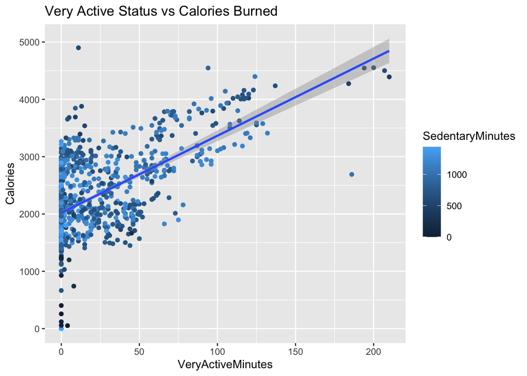

```r
ggplot(data = cleaned_activity, mapping = aes(x = VeryActiveMinutes, y = Calories)) + geom_point(aes(color = SedentaryMinutes)) + geom_smooth(method="lm", formula = y~x) + labs(title = "Very Active Status vs Calories Burned")
```

A positive correlation between very active status and calories burned is observed in this scatter plot, which indicates the longer duration in a very active status, the more calories they burned per day. Users in low activity and high sedentary status tend to burn less calories.

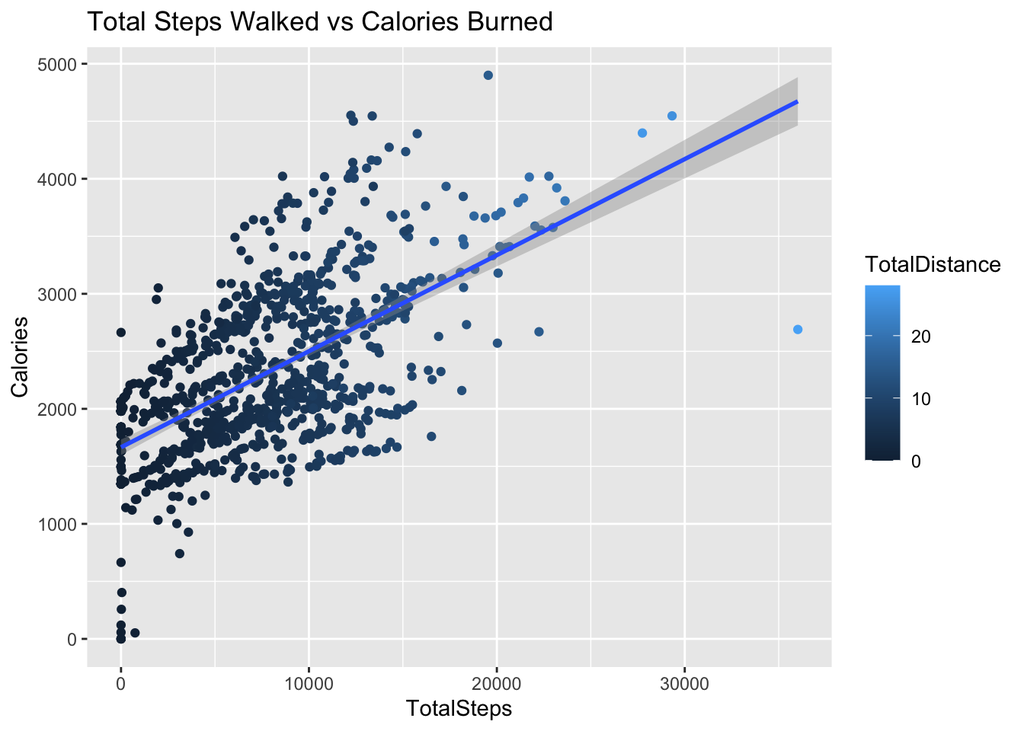

```r
ggplot(data = cleaned_activity, mapping = aes(x = TotalSteps, y = Calories)) + geom_point(aes(color = TotalDistance)) + geom_smooth(method="lm", formula = y~x) + labs(title = "Total Steps Walked vs Calories Burned")
```

There is also a positive relationship between total number of steps, total distance and calories burned. The total steps users walked in a specific distance is a significant factor in how many calories they burned while walking.

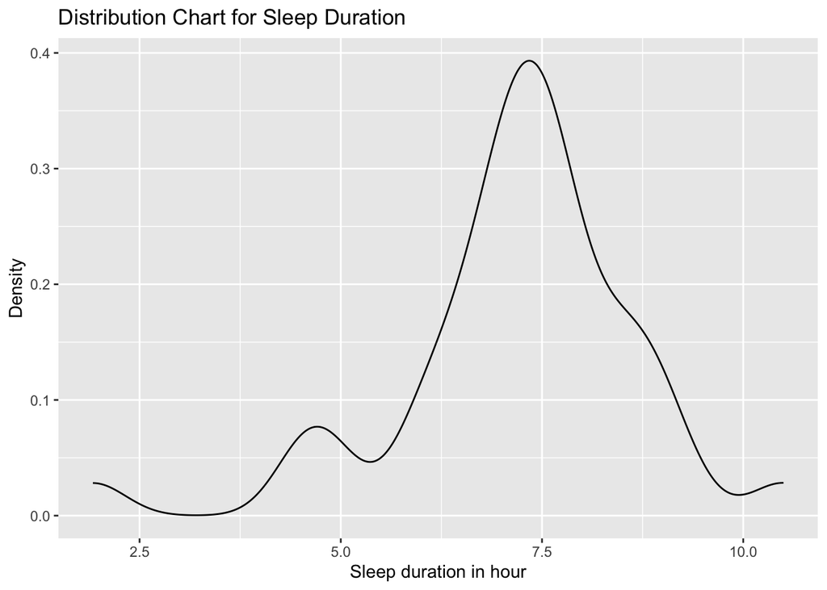

```r
ggplot(data = merged_activity_weight_sleep, mapping = aes(x = TotalHourAsleep)) + geom_density() + labs(title = "Distribution Chart for Sleep Duration", x = "Sleep duration in hour", y = "Density")
```

From the distribution chart for sleep duration as above, most of users spend around 5 to 10 hours in sleep per night, implying that nearly half do not meet the recommended sleep duration guideline which advises adults need between 7 and 9 hours of sleep per night. Further investigation is taken to determine if the length of sleep duration affects BMI and health.

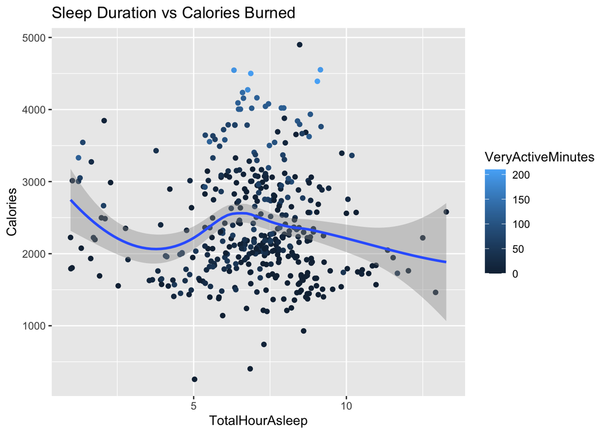

```r
ggplot(data = merged_activity_sleep, mapping = aes(x = TotalHourAsleep, y = Calories)) + geom_point(aes(color = VeryActiveMinutes)) + geom_smooth(method="loess", formula = y~x) + labs(title = "Sleep Duration vs Calories Burned")
```

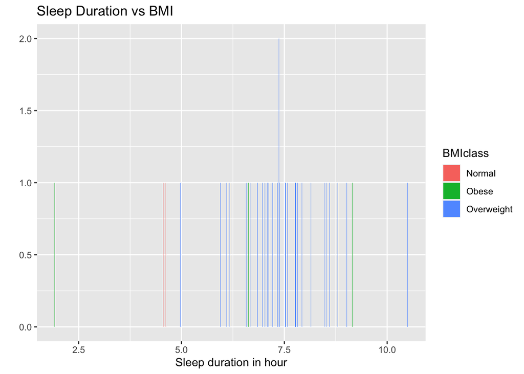

```r
ggplot(data = merged_activity_weight_sleep, mapping = aes(x = TotalHourAsleep)) + geom_bar(aes(fill = BMIclass)) + labs(title = "Sleep Duration vs BMI", x = "Sleep duration in hour", y="")
```

The above two charts show how sleep quality affects calories burned and BMI classification the users belong. Ignoring users with normal weight having less than 5 hours of sleep, we can draw a conclusion that relatively inactive users associated with both oversleeping and sleep deficit tend to depress the efficiency of calories burned, resulting in obesity.

## Stage 6: Act

Based on the findings in this analysis, there is a clear situation that people having more active and less sedentary lifestyle leads to a healthy body and good sleep quality. The insight is a useful way as data-driven recommendations to be applied to Bellabeat products in the future, as shown below:

- Set up alert functions in smart devices as a kind reminder for users tending to spend much time seated or inactive
- Expand periodic notifications motivating users to walk and exercise more
- Frequently update timely data record for users to monitor sleeping habits, as well as alert to avoid oversleeping